# Main report

Ana Martinovici

Last compiled on 2025-06-10 16:27:57.226666

This report provides information about how to use the Cat API and examples of the type of data you can collect.

# 1 Info about the Cat API

Go to https://developers.thecatapi.com to read more about this API, how to get access, and what type of information you can collect. For example: you need an API Key to collect more than 10 images. Getting an API key is relatively easy, see: https://thecatapi.com/ for info about what is available with the free access plan.

## 1.1 How to collect data

The file `cat_API/one_cat.R` shows the hello world equivalent of collecting data from the API.

These lines of code place the request:

```r
library("httr2")

my_request <- httr2::request(base_url = "https://api.thecatapi.com/v1/images/search")
my_request

my_request |>
    httr2::req_dry_run()

response <- my_request |>
    httr2::req_perform()

response |>
    httr2::resp_status()
response |>
    httr2::resp_status_desc()
response |>
    httr2::resp_content_type()
```

### 1.1.1 Data example

This is the photo collected with the example code:

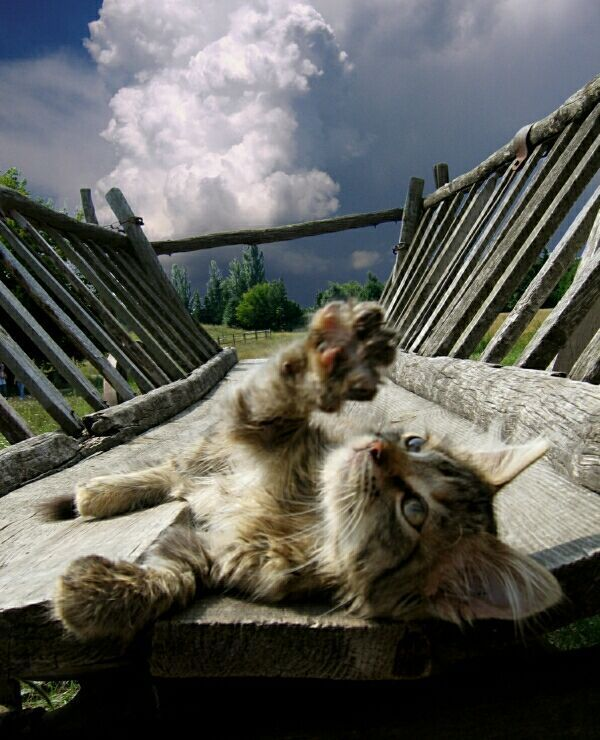

```r
knitr::include_graphics(path = here::here("cat_API", "photos", "one_cat.jpg"),
                        rel_path = FALSE)
```

## 1.2 Data collection

After checking that the simple example worked, I’ve extended the code to allow for collection of multiple observations and fields. Data collection took place in `cat_API/collect_data.R`. Multiple requests were placed with a filter on retrieving observations that have breed information.

The raw data collected from the API was saved within the repo and then processed by a separate script.

# 2 Data descriptives

Processed data is saved in `cat_API/process_data.RData`.

```r
library("tidyverse")
library("labelled")
library("kableExtra")
load(here::here("cat_API", "process_data.RData"))
```

We collected 220 observations. Each observation corresponds to a different cat. These observations cover 22 different cat breeds.

The API returned information about these variables:

```r
glimpse(df_cats)
```

```
## Rows: 220
## Columns: 6
## $ cat_number <chr> "cat1", "cat2", "cat3", "cat4", "cat5", "cat6", "cat7", "ca…
## $ obs_id     <chr> "xnzzM6MBI", "EHG3sOpAM", "unPP08xOZ", "N-94oSJ5T", "itfFA4…
## $ url        <chr> "https://cdn2.thecatapi.com/images/xnzzM6MBI.jpg", "https:/…
## $ width      <int> 2592, 1600, 2136, 1920, 1280, 3114, 1204, 1204, 1424, 1527,…
## $ height     <int> 1629, 1067, 2848, 1280, 914, 2609, 1445, 1107, 987, 1286, 1…
## $ breed_name <chr> "Abyssinian", "Abyssinian", "Abyssinian", "Abyssinian", "Ab…
```

```r
glimpse(df_breeds)
```

```
## Rows: 22
## Columns: 40
## $ id                 <chr> "abys", "aege", "abob", "acur", "asho", "awir", "am…
## $ name               <chr> "Abyssinian", "Aegean", "American Bobtail", "Americ…
## $ cfa_url            <chr> "http://cfa.org/Breeds/BreedsAB/Abyssinian.aspx", N…
## $ vetstreet_url      <chr> "http://www.vetstreet.com/cats/abyssinian", "http:/…
## $ vcahospitals_url   <chr> "https://vcahospitals.com/know-your-pet/cat-breeds/…
## $ temperament        <chr> "Active, Energetic, Independent, Intelligent, Gentl…
## $ origin             <chr> "Egypt", "Greece", "United States", "United States"…
## $ country_codes      <chr> "EG", "GR", "US", "US", "US", "US", "AE", "AU", "US…
## $ country_code       <chr> "EG", "GR", "US", "US", "US", "US", "AE", "AU", "US…
## $ description        <chr> "The Abyssinian is easy to care for, and a joy to h…
## $ life_span          <chr> "14 - 15", "9 - 12", "11 - 15", "12 - 16", "15 - 17…
## $ indoor             <int> 0, 0, 0, 0, 0, 0, 0, 0, 0, 0, 0, 0, 0, 0, 0, 0, 0, …
## $ lap                <int> 1, NA, 1, 1, 1, 1, NA, 1, NA, 0, 1, 1, NA, 1, 1, 1,…
```

[output cut: 27 more lines]

Further information about the values corresponding to these variables:

```r
labelled::look_for(df_cats) %>%
  kbl(escape = F, digits = c(2), align = c('r')) %>%
    kable_classic() %>%
    kable_styling(bootstrap_options = c("striped"), full_width = FALSE)
```

| pos | variable | label | col_type | missing | levels | value_labels |
| --- | --- | --- | --- | --- | --- | --- |
| 1 | cat_number | NA | chr | 0 | NULL | NULL |
| 2 | obs_id | NA | chr | 0 | NULL | NULL |
| 3 | url | NA | chr | 0 | NULL | NULL |
| 4 | width | NA | int | 0 | NULL | NULL |
| 5 | height | NA | int | 0 | NULL | NULL |
| 6 | breed_name | NA | chr | 0 | NULL | NULL |

```r
labelled::look_for(df_breeds, details = "full") %>%
  kbl(escape = F, digits = c(2), align = c('r')) %>%
    kable_classic() %>%
    kable_styling(bootstrap_options = c("striped"), full_width = FALSE)
```

| pos | variable | label | col_type | missing | levels | value_labels | class | type | na_values | na_range | n_na | unique_values | range |
| --- | --- | --- | --- | --- | --- | --- | --- | --- | --- | --- | --- | --- | --- |
| 1 | id | NA | chr | 0 | NULL | NULL | character | character | NULL | NULL | 0 | 22 | abob, lihu |
| 2 | name | NA | chr | 0 | NULL | NULL | character | character | NULL | NULL | 0 | 22 | Abyssinian , Egyptian Mau |
| 3 | cfa_url | NA | chr | 6 | NULL | NULL | character | character | NULL | NULL | 6 | 17 | http://cfa.org/Breeds/BreedsAB/Abyssinian.aspx , http://cfa.org/Breeds/BreedsCJ/EgyptianMau.aspx |
| 4 | vetstreet_url | NA | chr | 3 | NULL | NULL | character | character | NULL | NULL | 3 | 20 | http://www.vetstreet.com/cats/abyssinian, http://www.vetstreet.com/cats/li-hua |
| 5 | vcahospitals_url | NA | chr | 7 | NULL | NULL | character | character | NULL | NULL | 7 | 16 | , https://vcahospitals.com/know-your-pet/cat-breeds/egyptian-mau |
| 6 | temperament | NA | chr | 0 | NULL | NULL | character | character | NULL | NULL | 0 | 22 | Active, Curious, Easy Going, Playful, Calm , Lively, Social, Fun-loving, Relaxed, Affectionate |
| 7 | origin | NA | chr | 0 | NULL | NULL | character | character | NULL | NULL | 0 | 10 | Australia , United States |
| 8 | country_codes | NA | chr | 0 | NULL | NULL | character | character | NULL | NULL | 0 | 10 | AE, US |
| 9 | country_code | NA | chr | 0 | NULL | NULL | character | character | NULL | NULL | 0 | 10 | AE, US |
| 10 | description | NA | chr | 0 | NULL | NULL | character | character | NULL | NULL | 0 | 22 | American Bobtails are loving and incredibly intelligent cats possessing a distinctive wild appearance. They are extremely interactive cats that bond with their human family with great devotion. , This… |
| 11 | life_span | NA | chr | 0 | NULL | NULL | character | character | NULL | NULL | 0 | 14 | 10 - 15, 9 - 12 |
| 12 | indoor | NA | int | 0 | NULL | NULL | integer | integer | NULL | NULL | 0 | 2 | 0, 1 |
| 13 | lap | NA | int | 5 | NULL | NULL | integer | integer | NULL | NULL | 5 | 3 | 0, 1 |
| 14 | alt_names | NA | chr | 1 | NULL | NULL | character | character | NULL | NULL | 1 | 13 | , Spotted Mist |
| 15 | adaptability | NA | int | 0 | NULL | NULL | integer | integer | NULL | NULL | 0 | 3 | 2, 5 |
| 16 | affection_level | NA | int | 0 | NULL | NULL | integer | integer | NULL | NULL | 0 | 3 | 3, 5 |
| 17 | child_friendly | NA | int | 0 | NULL | NULL | integer | integer | NULL | NULL | 0 | 2 | 3, 4 |
| 18 | dog_friendly | NA | int | 0 | NULL | NULL | integer | integer | NULL | NULL | 0 | 3 | 3, 5 |
| 19 | energy_level | NA | int | 0 | NULL | NULL | integer | integer | NULL | NULL | 0 | 4 | 2, 5 |
| 20 | grooming | NA | int | 0 | NULL | NULL | integer | integer | NULL | NULL | 0 | 4 | 1, 5 |
| 21 | health_issues | NA | int | 0 | NULL | NULL | integer | integer | NULL | NULL | 0 | 3 | 1, 3 |
| 22 | intelligence | NA | int | 0 | NULL | NULL | integer | integer | NULL | NULL | 0 | 3 | 3, 5 |
| 23 | shedding_level | NA | int | 0 | NULL | NULL | integer | integer | NULL | NULL | 0 | 5 | 1, 5 |
| 24 | social_needs | NA | int | 0 | NULL | NULL | integer | integer | NULL | NULL | 0 | 3 | 3, 5 |
| 25 | stranger_friendly | NA | int | 0 | NULL | NULL | integer | integer | NULL | NULL | 0 | 4 | 2, 5 |
| 26 | vocalisation | NA | int | 0 | NULL | NULL | integer | integer | NULL | NULL | 0 | 3 | 1, 5 |
| 27 | experimental | NA | int | 0 | NULL | NULL | integer | integer | NULL | NULL | 0 | 1 | 0, 0 |
| 28 | hairless | NA | int | 0 | NULL | NULL | integer | integer | NULL | NULL | 0 | 1 | 0, 0 |
| 29 | natural | NA | int | 0 | NULL | NULL | integer | integer | NULL | NULL | 0 | 2 | 0, 1 |
| 30 | rare | NA | int | 0 | NULL | NULL | integer | integer | NULL | NULL | 0 | 1 | 0, 0 |
| 31 | rex | NA | int | 0 | NULL | NULL | integer | integer | NULL | NULL | 0 | 2 | 0, 1 |
| 32 | suppressed_tail | NA | int | 0 | NULL | NULL | integer | integer | NULL | NULL | 0 | 2 | 0, 1 |
| 33 | short_legs | NA | int | 0 | NULL | NULL | integer | integer | NULL | NULL | 0 | 1 | 0, 0 |
| 34 | wikipedia_url | NA | chr | 0 | NULL | NULL | character | character | NULL | NULL | 0 | 22 | https://en.wikipedia.org/wiki/Abyssinian_(cat), https://en.wikipedia.org/wiki/Egyptian_Mau |
| 35 | hypoallergenic | NA | int | 0 | NULL | NULL | integer | integer | NULL | NULL | 0 | 2 | 0, 1 |
| 36 | reference_image_id | NA | chr | 0 | NULL | NULL | character | character | NULL | NULL | 0 | 22 | _6x-3TiCA, xnsqonbjW |
| 37 | weight_imperial | NA | chr | 0 | NULL | NULL | character | character | NULL | NULL | 0 | 18 | 12 - 20, 9 - 12 |
| 38 | weight_metric | NA | chr | 0 | NULL | NULL | character | character | NULL | NULL | 0 | 9 | 2 - 4, 5 - 9 |
| 39 | cat_friendly | NA | int | 19 | NULL | NULL | integer | integer | NULL | NULL | 19 | 4 | 2, 4 |
| 40 | bidability | NA | int | 21 | NULL | NULL | integer | integer | NULL | NULL | 21 | 2 | 3, 3 |